# AFDMD-111 - Estadística

Distribuciones muestrales

Armando Patricio Piña Canul

27/11/2023

# Distribuciones muestrales de la media

En esta práctica abordaremos el tema de la distribución muestral de la media para diversas distribuciones de probabilidad y veremos como éstas se ajustan a una distribución de probabilidad normal o Gaussiana como la que se muestra en la ecuación,

$$f_X(x) = \frac{1}{\sqrt{2\pi \sigma^2}}
\mbox{e}^{-\frac{-(x-\mu)^2}{2\sigma^2}}$$

Antes de iniciar, es necesario que nos familiaricemos con los siguientes comandos:

```r
#hist()
#qqnorm()
#qqline()
```

para ello podemos hacer `help(comando)` y obtener ayuda sobre cada uno de ellos. Ahora responda lo siguiente.

1. ¿Cuál es la función del comando `qqnorm`?.
2. ¿Cuál es la función del comando `qqline`? ¿y de `hist`?.

## Aplicación de `qqnorm` y `qqline`

Veamos ahora la aplicación de `qqnorm` y `qqline` en un ejemplo práctico. Supóngamos que queremos verificar si los datos se ajustan a una distribución normal, entonces para hacerlo, aplicamos,

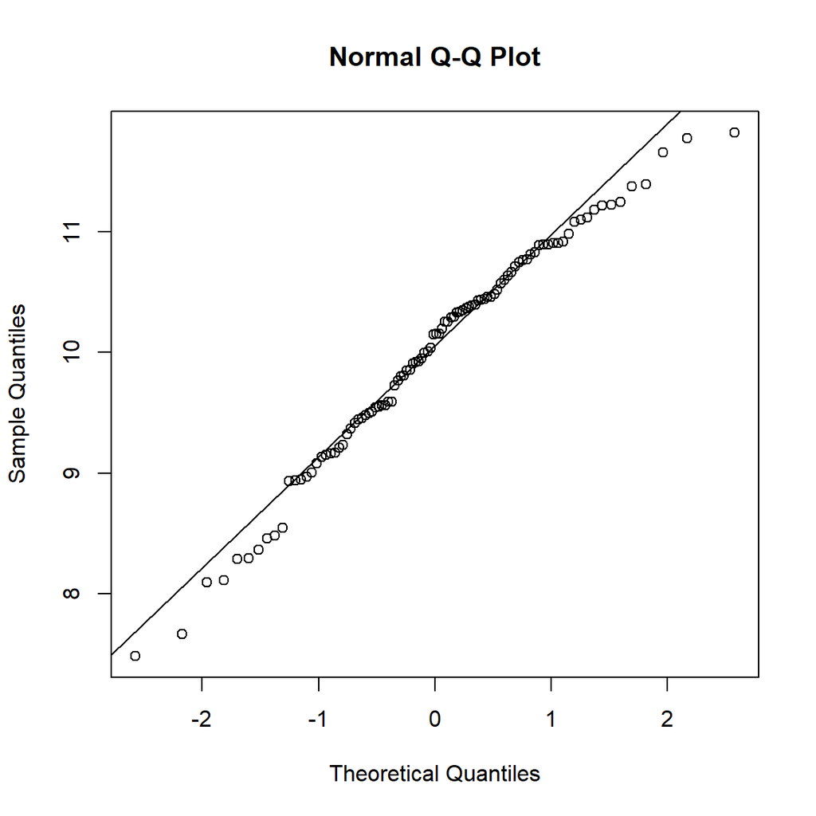

```r
datos <- rnorm(100, mean = 10)
qqnorm(datos)
qqline(datos)
```

Actividad.

1. Ahora cambie los nombres de los ejes $x$, $y$ y del título del gráfico anterior.

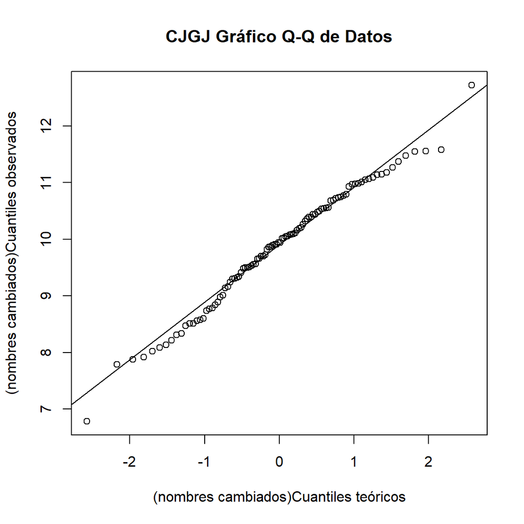

```r
datos <- rnorm(100, mean = 10)
qqnorm(datos, xlab="(nombres cambiados)Cuantiles teóricos", ylab="(nombres cambiados)Cuantiles observados", main="CJGJ Gráfico Q-Q de Datos")
qqline(datos)
```

2. ¿Qué sucede si la longitud de los datos es pequeña, digamos 10, 20 (modifique `rnorm`)?

Cuando la longitud de los datos es pequeña, el gráfico Q-Q puede no proporcionar una evaluación precisa de la normalidad debido a la limitada cantidad de datos.

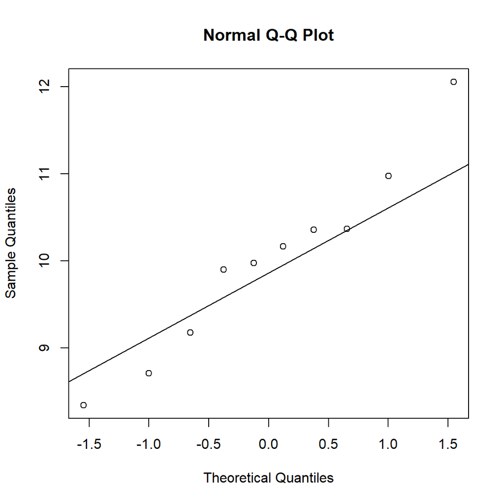

```r
datos <- rnorm(10, mean = 10)
qqnorm(datos)
qqline(datos)
```

3. ¿Qué sucede si los datos tienen varianza grande? ¿En qué parte del gráfico Q-Q se puede ver la varianza grande?

4. ¿Y si cambiamos la media?

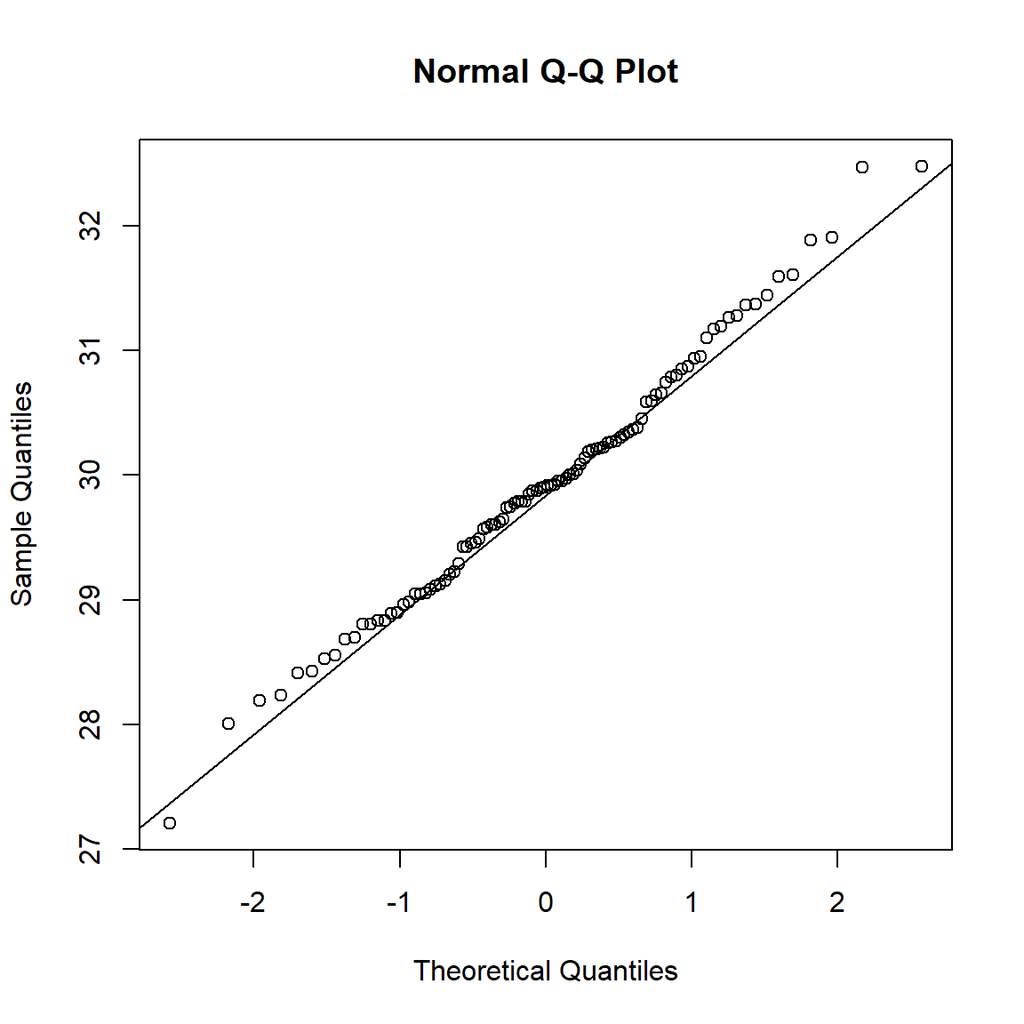

```r
datos <- rnorm(100, mean = 30)
qqnorm(datos)
qqline(datos)
```

5. ¿Qué sucede si los datos son exponenciales?

El gráfico reflejará las características particulares de la distribución exponencial en lugar de la forma diagonal que se esperaría con una distribución normal.

## Aplicación de `hist`

El comando `hist` permite obtener el histograma de una serie de datos. El histograma, de igual forma que el gráfico Q-Q permite ajustar una serie de datos a una distribución para saber qué tanto se parece a la densidad teórica. Veamos cómo se aplica.

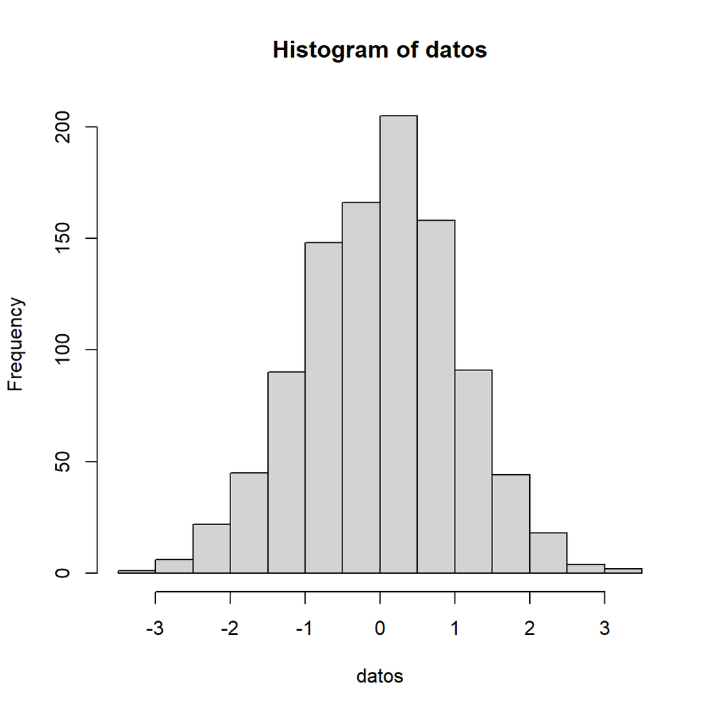

```r
datos <- rnorm(1000) #1000 muestras de una densidad normal
hist(datos)
```

Podemos ver en el gráfico del histograma que éste es similar al gráfico de la densidad. El siguiente código lo muestra:

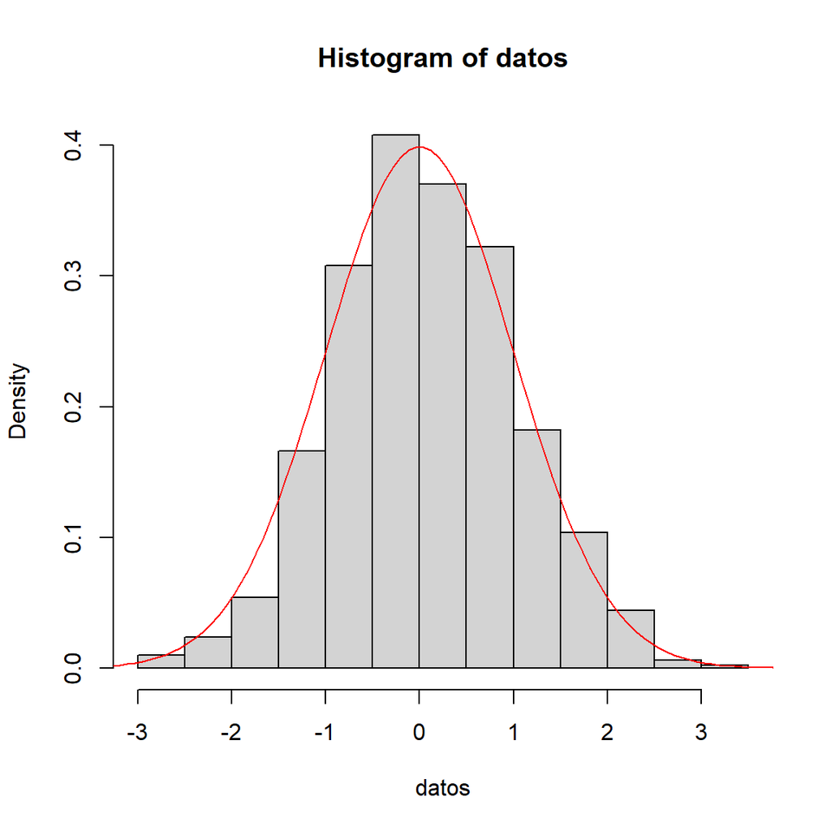

```r
datos <- rnorm(1000) # muestras normales con media 0 y var 1.
teorica <- dnorm(seq(-4,4, length=100),mean = 0, sd = 1)
hist(datos,freq = FALSE)
lines(seq(-4,4, length=100),teorica, col="red")
```

Actividades.

1. ¿Qué sucede si el número de muestras es pequeño (muestrelo mediante código y gráficas)?

La representación de la distribución de probabilidad de las muestras puede ser menos precisa y más susceptible a variaciones aleatorias.

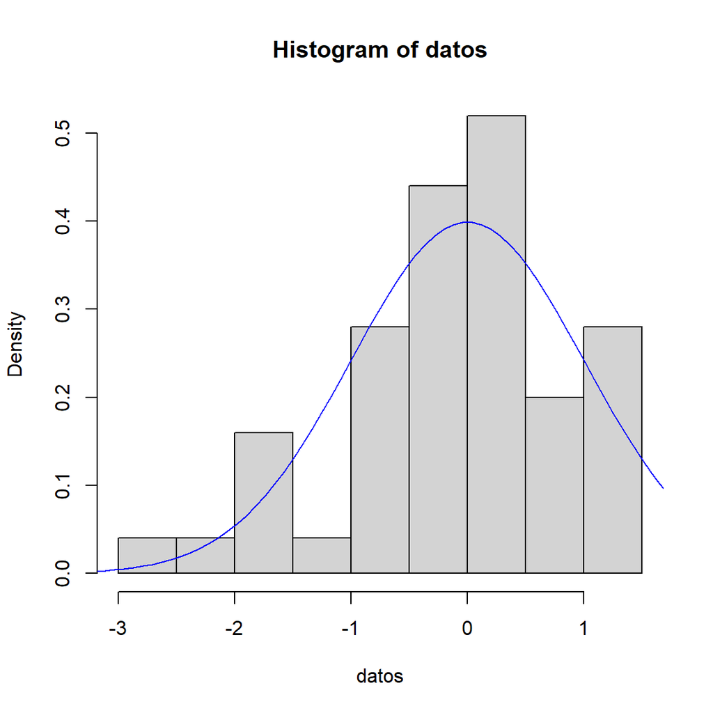

```r
datos <- rnorm(50) # muestras normales con media 0 y var 1.
teorica <- dnorm(seq(-4,4, length=100),mean = 0, sd = 1)
hist(datos,freq = FALSE)
lines(seq(-4,4, length=100),teorica, col="blue")
```

2. ¿Y si cambio la varianza? ¿Tiene algún efecto la varianza grande? Mostrar con código.  
   Aumentar la varianza resulta en una mayor dispersión de los datos alrededor de la media. cambiar la varianza tiene un efecto claro en la forma y la dispersión de la distribución normal. A mayor varianza, la distribución será más ancha y los datos estarán más dispersos alrededor de la media.

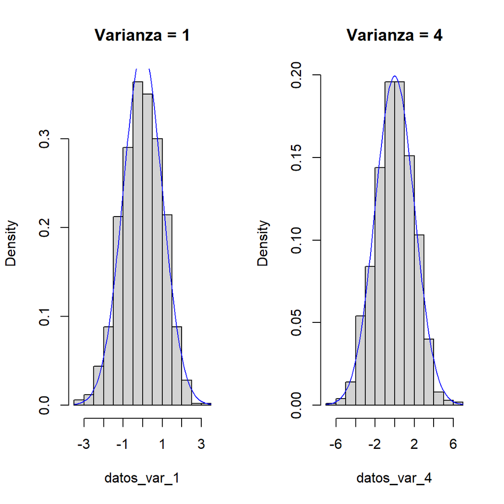

```r
datos_var_1 <- rnorm(1000, mean = 0, sd = 1)
datos_var_4 <- rnorm(1000, mean = 0, sd = 2)  # Varianza = sd^2

# Crear un histograma para varianza 1
par(mfrow = c(1, 2))  # Configurar la disposición de los gráficos
hist(datos_var_1, freq = FALSE, main = "Varianza = 1")
curve(dnorm(x, mean = 0, sd = 1), add = TRUE, col = "blue")

# Crear un histograma para varianza 4
hist(datos_var_4, freq = FALSE, main = "Varianza = 4")
curve(dnorm(x, mean = 0, sd = 2), add = TRUE, col = "blue")
```

3. ¿Cuáles crees que son las ventajas y desventajas del histograma y el gráfico Q-Q?

**Ventajas y desventajas del histograma:**

Ventajas:

- Visualización de la distribución: El histograma proporciona una representación visual directa de la distribución de los datos, permitiendo identificar patrones, modas y simetría.
- Facilidad de interpretación: Es fácil de entender incluso para personas no familiarizadas con estadísticas. La altura de las barras refleja la frecuencia de ocurrencia de los valores.
- Identificación de tendencias: Puede ayudar a identificar tendencias, agrupamientos y anomalías en los datos.
- Versatilidad: Puede ajustarse fácilmente para cambiar el número de barras, su ancho y otras configuraciones para adaptarse a la situación.

Desventajas:

- Sensibilidad a la elección de intervalos: Los resultados pueden variar significativamente dependiendo de cómo se elijan los intervalos para construir el histograma.
- Pérdida de información: Al agrupar datos en intervalos, se pierde información detallada sobre la variabilidad de los datos.
- Dependencia del tamaño de la muestra: La apariencia del histograma puede variar según el tamaño de la muestra, y puede no revelar la verdadera forma de la distribución si la muestra es pequeña.

**Ventajas y desventajas del gráfico Q-Q:**

Ventajas:

- Comparación con la distribución teórica: El gráfico Q-Q compara cuantiles observados con los cuantiles teóricos de una distribución específica, permitiendo evaluar si los datos siguen una distribución conocida.
- Identificación de desviaciones de la normalidad: Es especialmente útil para evaluar la normalidad de los datos. Si los puntos se ajustan bien a la línea diagonal, los datos pueden aproximarse a una distribución normal.
- Resistencia a la escala: El gráfico Q-Q es menos sensible a la escala de los datos en comparación con otros gráficos de probabilidad.

Desventajas:

- Requiere conocimiento previo: La interpretación del gráfico Q-Q puede requerir cierto conocimiento estadístico para comprender completamente los conceptos de cuantiles y distribuciones teóricas.
- Limitado para evaluar formas específicas: Aunque es útil para evaluar la normalidad, puede no ser tan efectivo para identificar desviaciones de otras formas de distribución.
- No revela información detallada: Al igual que el histograma, el gráfico Q-Q no revela información detallada sobre la variabilidad de los datos y se centra más en la forma general de la distribución.

# Aplicación de la distribución muestral de la media.

El término distribución muestral de la media se refiera a la distribución (ajustada mediante el gráfico Q-Q o el histograma) de la media muestral de un conjunto de datos. Por ejemplo,

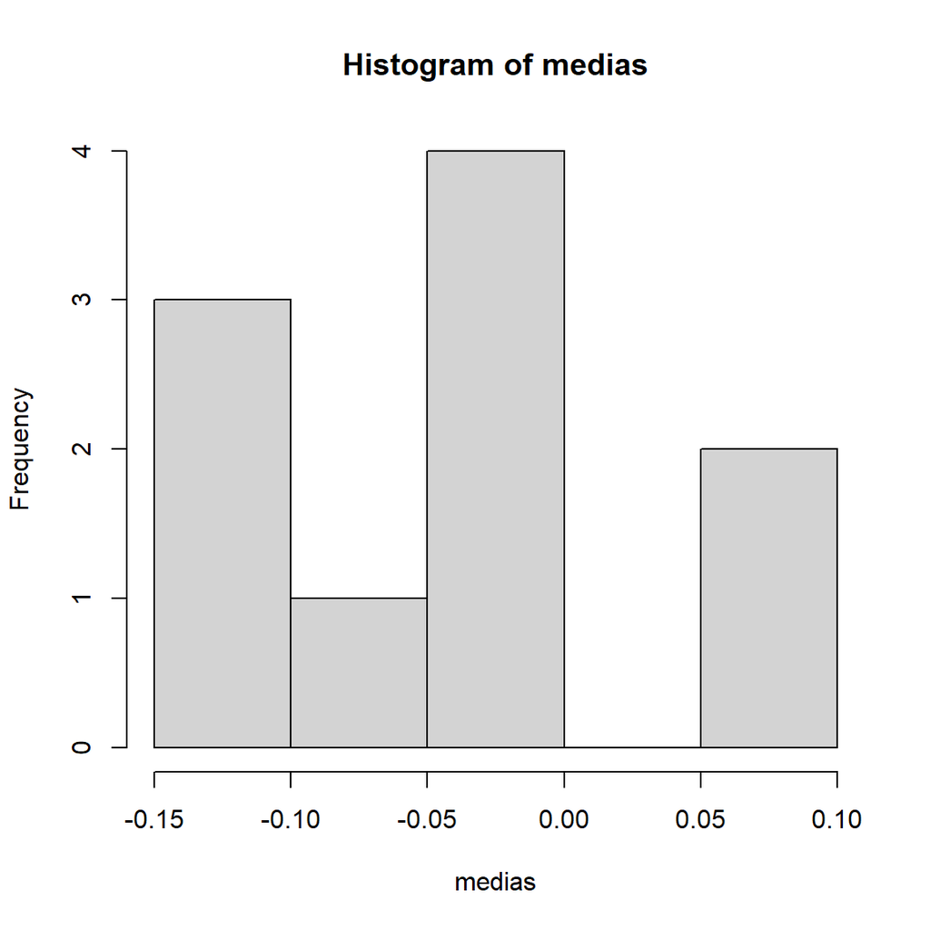

```r
N <- 10 # número de medias (es decir número de muestras)
M <- 100 # número de la longitud de cada serie de datos
medias <- numeric(N) # Vector que guardará las medias

for(i in 1:N)
{
  datos <- rnorm(M)
  medias[i] <- mean(datos)

}
hist(medias)
```

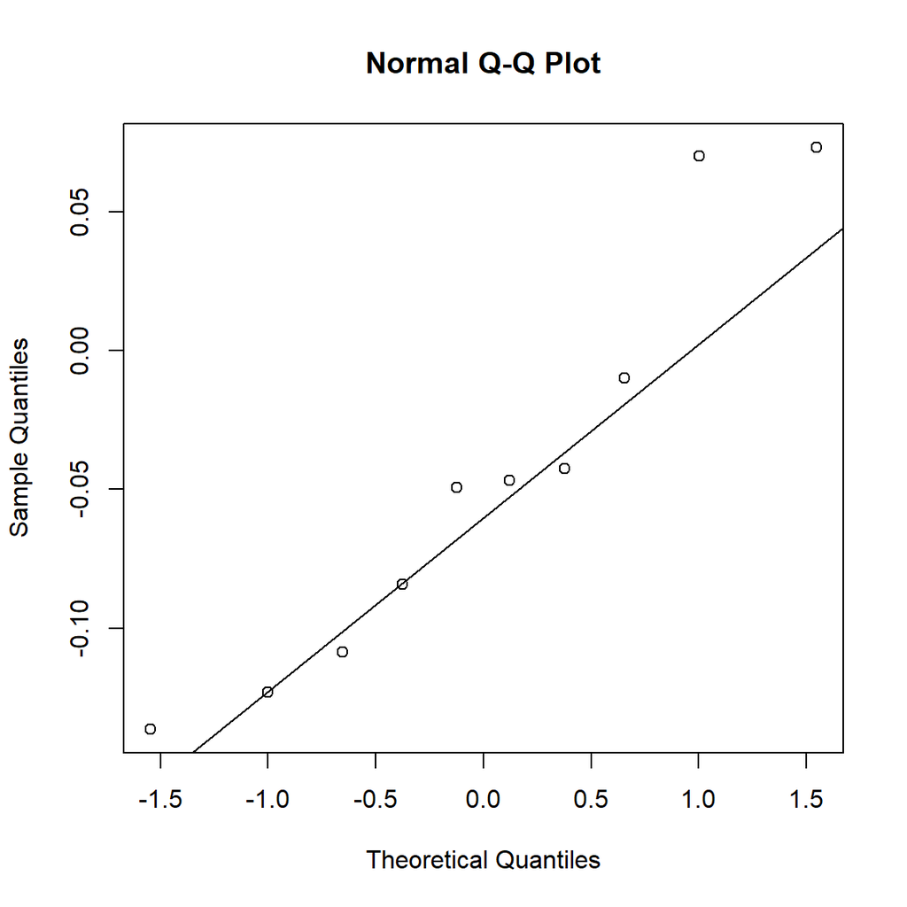

```r
qqnorm(medias)
qqline(medias)
```

Actividad

1. ¿Qué sucede si hago N grande, por ejemplo 100, 1000, 10000?

Las medias se asemeja cada vez más a una distribución normal.

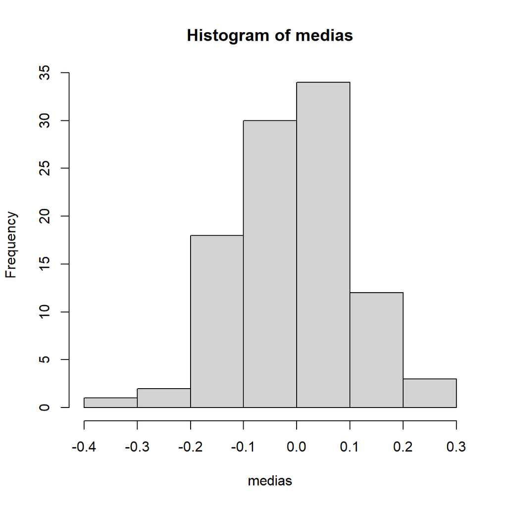

```r
N <- 100
M <- 100
medias <- numeric(N)
for(i in 1:N)
{
  datos <- rnorm(M)
  medias[i] <- mean(datos)
}
hist(medias)
```

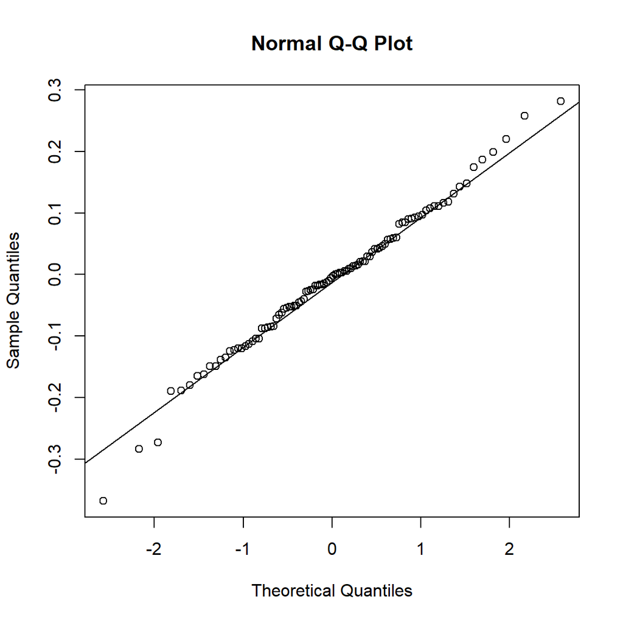

```r
qqnorm(medias)
qqline(medias)
```

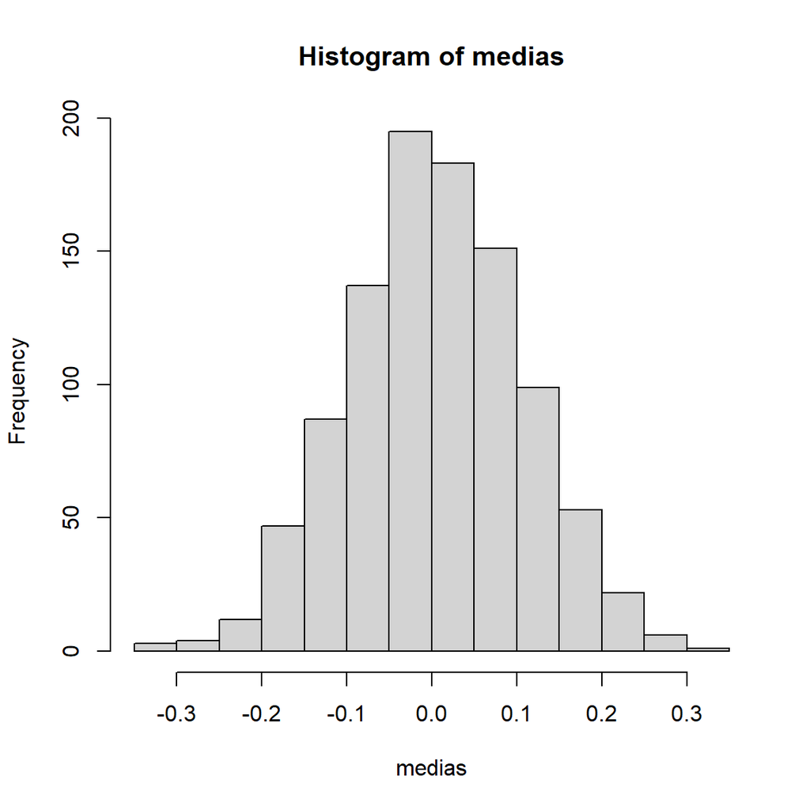

```r
N <- 1000
M <- 100
medias <- numeric(N)
for(i in 1:N)
{
  datos <- rnorm(M)
  medias[i] <- mean(datos)
}
hist(medias)
```

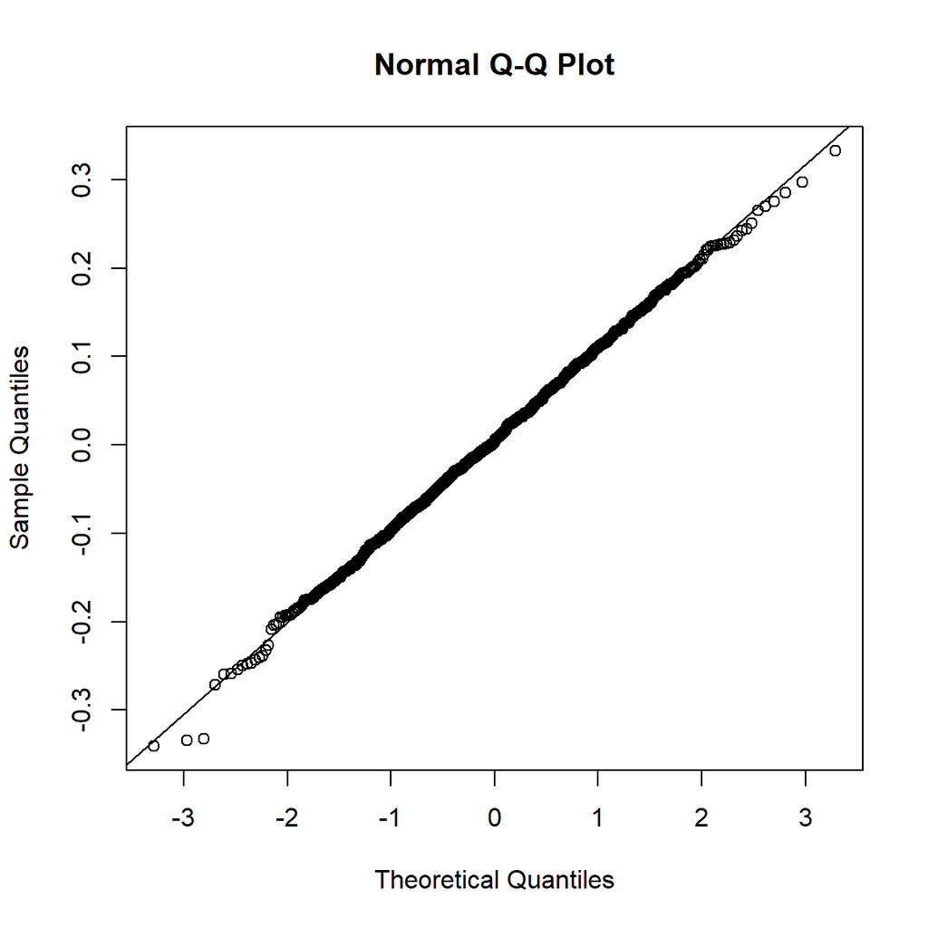

```r
qqnorm(medias)
qqline(medias)
```

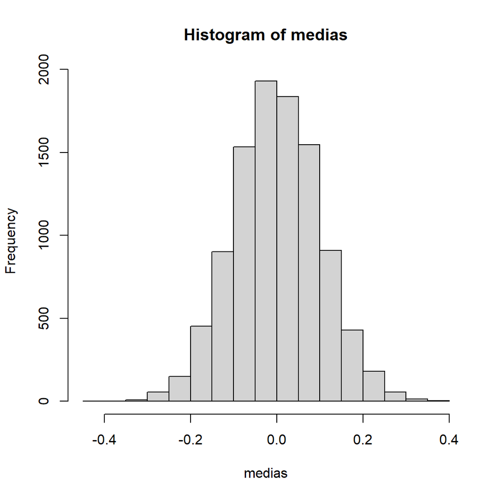

```r
N <- 10000
M <- 100
medias <- numeric(N)
for(i in 1:N)
{
  datos <- rnorm(M)
  medias[i] <- mean(datos)
}
hist(medias)
```

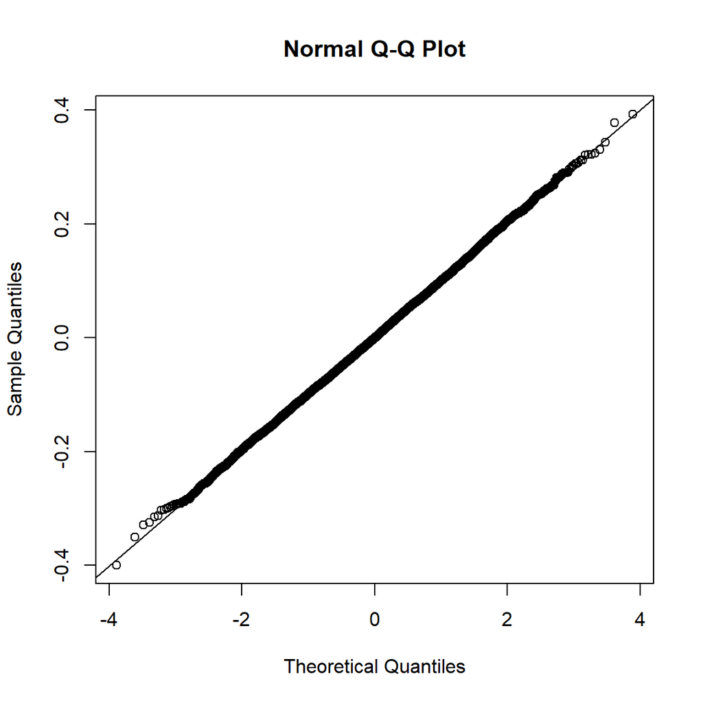

```r
qqnorm(medias)
qqline(medias)
```

2. ¿Qué sucede si en lugar de tomar una muestra Gaussiana, tomo una muestra exponencial con N muy grande?

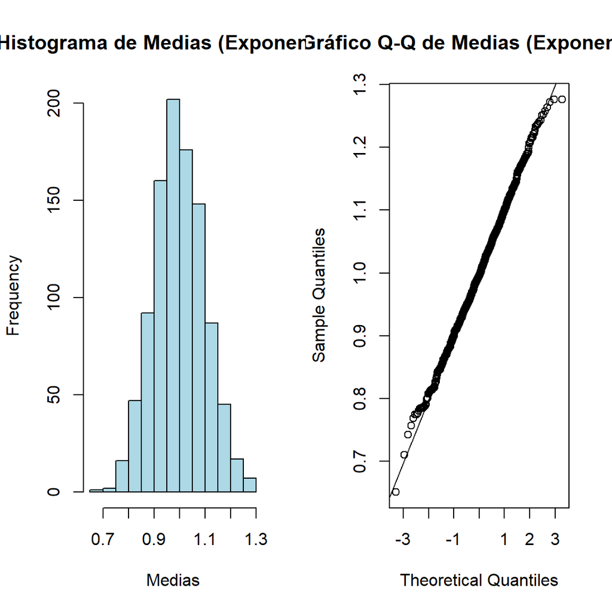

```r
N <- 1000
M <- 100
medias_exp <- numeric(N)

for (i in 1:N) {
  datos_exp <- rexp(M)
  medias_exp[i] <- mean(datos_exp)
}
par(mfrow = c(1, 2))
hist(medias_exp, main = "Histograma de Medias (Exponencial)", col = "lightblue", xlab = "Medias")
qqnorm(medias_exp, main = "Gráfico Q-Q de Medias (Exponencial)")
qqline(medias_exp)
```

## Fecha de entrega: Miércoles 29 de Noviembre de 2023 ha las 16:00HRS